# RelatorioLAB01

José Alberto Souza Paulino

28/03/2022

## Questão 01

*Calcule média e desvio padrão da idade e nível de interesse. As métricas contendos as métricas calculadas para idade e devem ser apresentadas de forma ordenada, da maior idade para a menor. Além de apresentar no relatório, os resultados devem ser salvos em um arquivo csv, que deve ser adicionado ao repositório.* !

### 01.01 Média e desvio padrão para idade dos alunos da turma de FPCC II:

```
## [1] "Média das idades: 29.6666666666667"
```

```
## [1] "Desvio padrão das idades: 5.79855054352354"
```

### 01.02 Média e desvio padrão para o número de alunos de FPCC II de acordo com o nível de confiança em progração R:

| prog_r | media | des_padrao |
| --- | --- | --- |
| Bastante confiante | 0.0833333 | 1.916667 |
| Médio | 0.3333333 | 7.666667 |
| Nenhuma confiança | 0.2916667 | 6.708333 |
| Um pouco | 0.2916667 | 6.708333 |

```r
write.csv(temp012, "Metricas_nivel_confianca_ProgR.csv", row.names = TRUE)
```

## Questão 02

*Qual o curso com maior valor médio de idade? Discutir os resultados com base nos dados disponíveis em termos de representatividade.*

| tipo_curso | media_idade |
| --- | --- |
| Doutorado | 35.66667 |
| Mestrado | 28.80952 |

A média da idade dos alunos de mestrado estão bem próximos da média geral, já a média para alunos de doutorado está bem acima da média geral.

## Questão 03

*Crie um gráfico que mostra a idade média para cada curso. Apresente o gráfico e discuta os resultados no relatório. O gráfico também deve ser salvo em uma imagem no formato png, que deve ser adicionada ao repositório.*

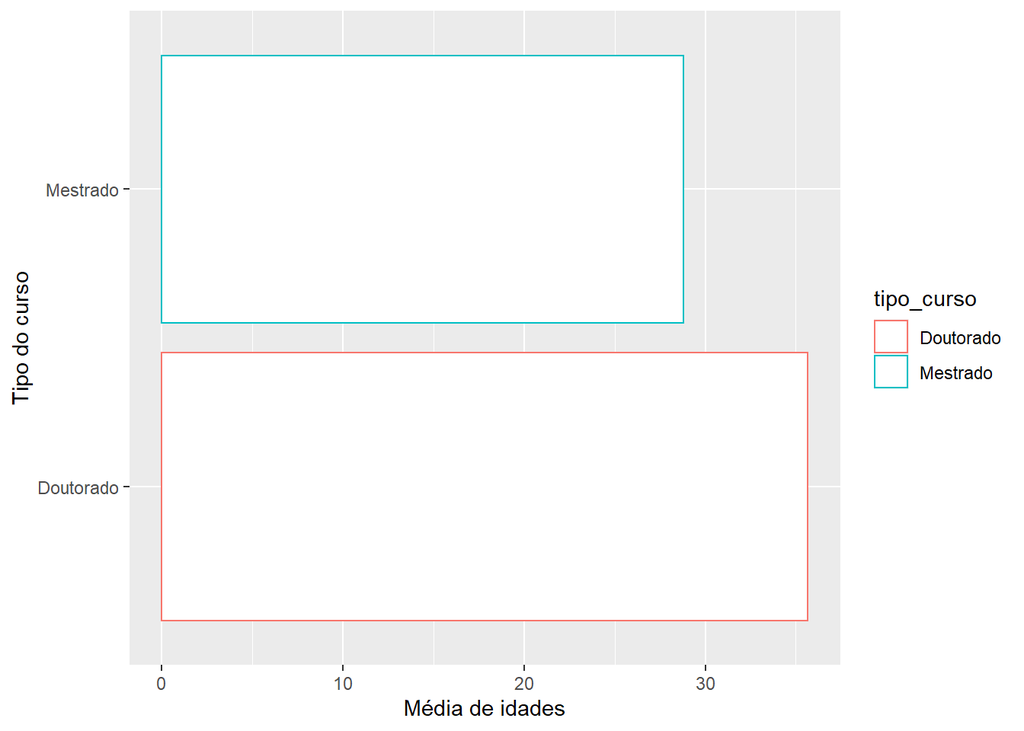

Curso de doutorado apresenta média de idade maior que o curso de mestrado. Esta observação é compreensível uma vez que, em geral, o aluno de doutorado já passou pelo mestrado e se espera, que a faixa etária seja um pouco maior.

## Questão 04

*Crie um gráfico que mostra o percentual de alunos para cada estado de origem. Apresente o gráfico e discuta os resultados no relatório. O gráfico também deve ser salvo em uma imagem no formato png, que deve ser adicionada ao repositório.*

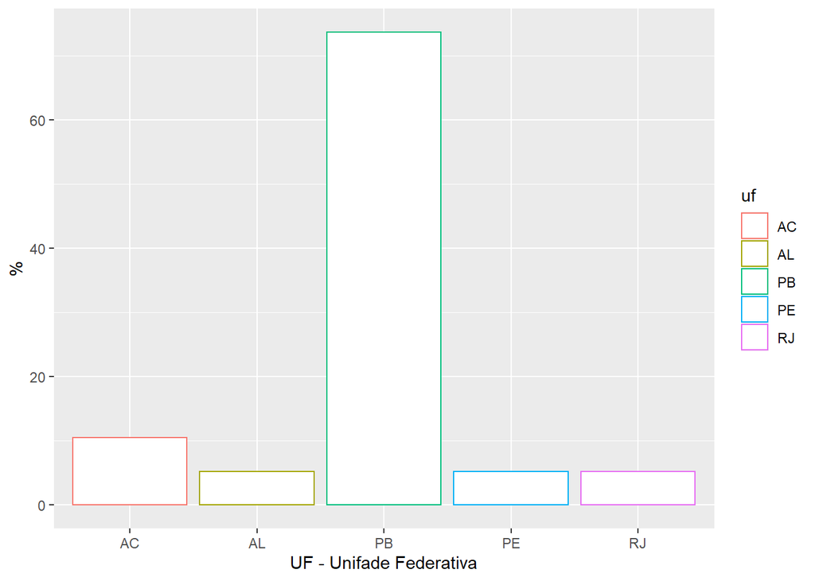

Os alunos residentes na Paraíba constituim mais de 70% no curso.

## Questão 05

*Compare a média de idade geral com a média de idade dos top-5 e dos bottom-5. Além de apresentar e discutir os resultados no relatório, salvar em uma tabela (dataframe) com as médias em questão.*

| MEDIA | VALOR |
| --- | --- |
| Med_TOP5 | 27.8333333333333 |
| Med_BOTTOM5 | 31.5 |
| Med_Geral | 29.6666666666667 |

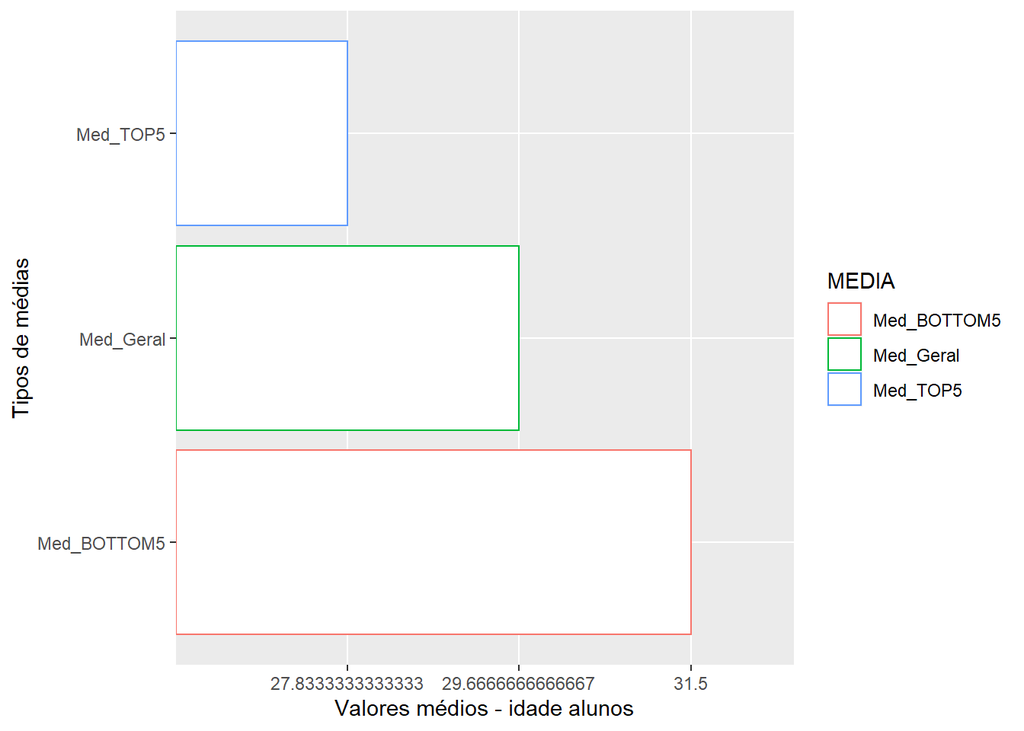